# R Notebook: Duncan

Id: Name of profession type: Type of occupation: prof, professional and managerial; wc, white-collar; bc, bluecollar. income: Percent of males in occupation earning $3500 or more in 1950. education: Percent of males in occupation in 1950 who were high-school graduates. prestige: Percent of raters in NORC study rating occupation as excellent or good in prestige. -https://socialsciences.mcmaster.ca/jfox/Books/Applied-Regression-2E/datasets/Duncan.pdf

# Libraries

```r
library(tidyverse)
library(olsrr)
library(GGally)
library(psych)
library(lmtest)
library(car)
library(broom)
library(boot)
library(modelr)
library(car)
```

```r
duncan <- read_csv("Duncan.csv ")
```

```r
describe(duncan)
```

[output not shown]

```
          vars  n  mean    sd median trimmed   mad min  max range skew kurtosis   se
id*          1 45   NaN    NA     NA     NaN    NA Inf -Inf  -Inf   NA       NA   NA
income       2 45 41.87 24.44     42   41.57 32.62   7   81    74 0.11    -1.44 3.64
education    3 45 52.56 29.76     45   51.86 37.06   7  100    93 0.22    -1.61 4.44
prestige     4 45 47.69 31.51     41   47.30 44.48   3   97    94 0.14    -1.55 4.70
type*        5 45   NaN    NA     NA     NaN    NA Inf -Inf  -Inf   NA       NA   NA
```

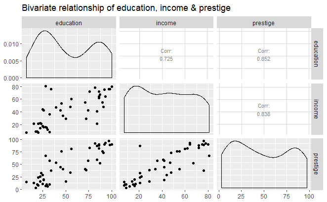

```r
scatterplot <- ggpairs(duncan, columns = c("education", "income", "prestige"),
    upper = list(continuous = wrap("cor", size = 3)),
    title = "Bivariate relationship of education, income & prestige" )
print(scatterplot, progress = FALSE)
```

All correlations appear to relatively high. Additionally, They sems to be somwhat linear, however, I am a little concerned with the relatioship between prestige and education. I am also a little concerned with the education histigram. It seems sort of odd. Almost as if it is approaching 2 modes.

```r
dun_lin <- lm(data = duncan, prestige ~ education + income)
ols_regress(dun_lin)
```

```
                         Model Summary
---------------------------------------------------------------
R                       0.910       RMSE                13.369
R-Squared               0.828       Coef. Var           28.034
Adj. R-Squared          0.820       MSE                178.731
Pred R-Squared          0.796       MAE                  9.677
---------------------------------------------------------------
 RMSE: Root Mean Square Error
 MSE: Mean Square Error
 MAE: Mean Absolute Error

                                ANOVA
----------------------------------------------------------------------
                 Sum of
                Squares        DF    Mean Square       F         Sig.
----------------------------------------------------------------------
Regression    36180.946         2      18090.473    101.216    0.0000
Residual       7506.699        42        178.731
Total         43687.644        44
----------------------------------------------------------------------

                                  Parameter Estimates
----------------------------------------------------------------------------------------
      model      Beta    Std. Error    Std. Beta      t        Sig       lower    upper
----------------------------------------------------------------------------------------
(Intercept)    -6.065         4.272                 -1.420    0.163    -14.686    2.556
  education     0.546         0.098        0.516     5.555    0.000      0.348    0.744
     income     0.599         0.120        0.464     5.003    0.000      0.357    0.840
----------------------------------------------------------------------------------------
```

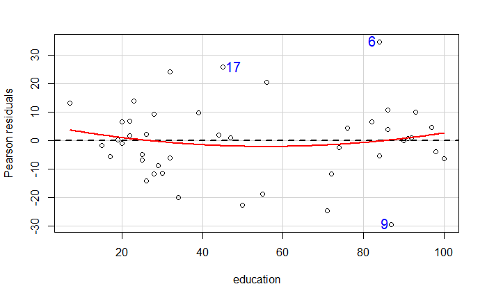

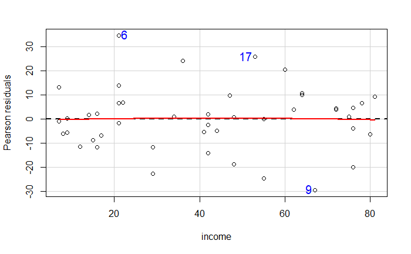

```
           Test stat Pr(>|t|)
education      0.672    0.505
income        -0.113    0.911
Tukey test    -0.081    0.935
```

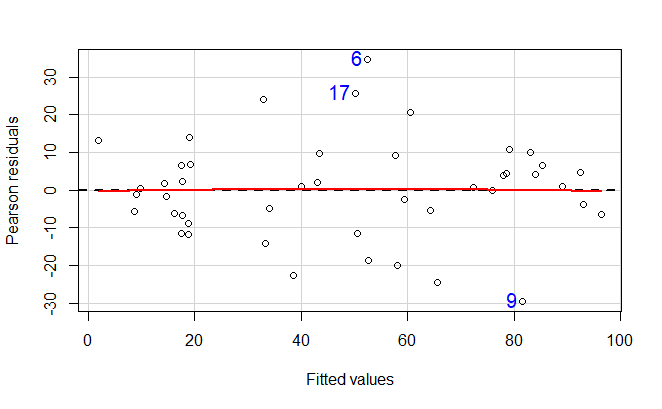

```r
car::residualPlots(dun_lin, ask = FALSE, id.n = 3, labels.id = names(id), id.cex= 1.25, id.col = "blue", layout = c(1,1))
```

Looking at these plots, my main concern is how our residuals are with the education residuals are correlating with unexplained y-hat in prestige. However, our fitted values appear fine. There is no correlation between the model residuals and the y-hat. However, because education is a variable of interest, I am concerned. Additionally, when we look at our significance test, there doesn’t appear to be evidence of too much curvature among any of them.

## Component + residual plot

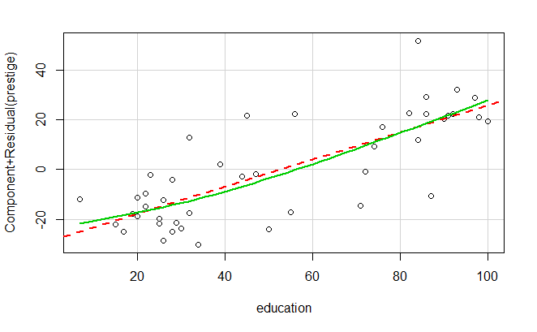

```r
crPlots(dun_lin, ask = FALSE, terms = "education")
```

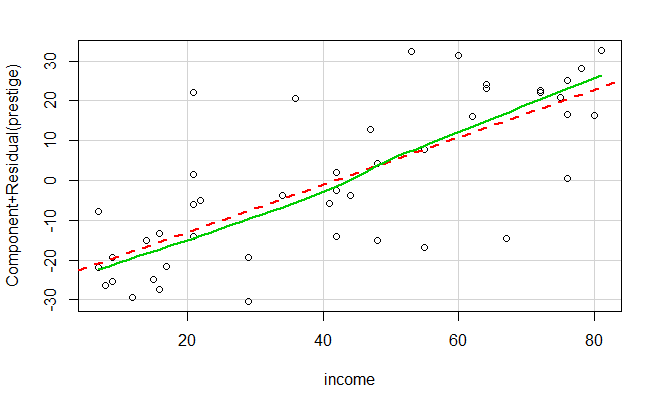

```r
crPlots(dun_lin, ask = FALSE, terms = "income")
```

Looking at these plots, I can see the same trend I was seeing with education as before. Education does no seem to exactly have the most linear trend. However, it does not seem to deviate too much. Which makes me think, that for the most part, this may still fit as a linear trend.

## Homoscedacity interpretation

I think that education looks fine and there is not much scedacity because it is overall pretty evenly distributed as far how they are spread out. There doesn’t seem to be much fanning out. However. I feel like there is a bit of fanning in income when I look at it.

```r
car::ncvTest(dun_lin)
```

```
Non-constant Variance Score Test
Variance formula: ~ fitted.values
Chisquare = 0.3810967    Df = 1     p = 0.5370169
```

Looking at the p-value from the chi-square results, we can see that there is no evidence (statistically speaking) of violating the homoscedacity assumption in our model.

# Normality of errors

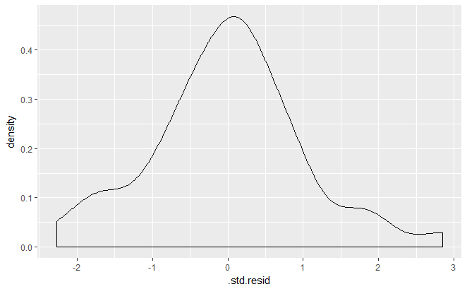

```r
fit_dun_lin <- broom::augment(dun_lin, data=duncan)
ggplot(data = fit_dun_lin, aes(x = .std.resid)) +
         geom_density()
```

The standardized residuals for our model seems relatively normal. I wouldn’t have it cause me too much concern. The leftover residuals are spread relatively evenly.

```
 9 17  6
 1 44 45
```

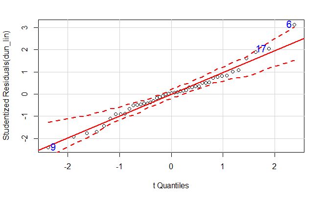

```r
qqPlot(dun_lin, ask = FALSE, id.n = 3, labels.id = names(id), id.cex = 1.25, id.col = "blue")
```

```r
shapiro.test(fit_dun_lin$.resid)
```

```
    Shapiro-Wilk normality test

data:  fit_dun_lin$.resid
W = 0.98254, p-value = 0.7234
```